# Readme

Zilu

November 20, 2018

# Spectronaut library summary

## Libraries exported from Spectronaut (.xls format)

```r
library(ggplot2)
dir("Spectronaut Library List/Original List")
```

```
##  [1] "170513_Fusion_(LC2)_Zilu_Hek_SC_Trypsin_VVA_HRM_2h_HCD_DDA(400-1200)_4xR_Tn_Final(G).xls"
##  [2] "171017_Fusion_(LC2)_Zilu_Hek_SC_Trypsin_VVA_HRM_2h_HCD_DDA_High_pH_1_20(Perq)_T_Tn_Final(G).xls"
##  [3] "180102_Capan1_SC_Try_deSA_8xFR.xls"
##  [4] "180102_Ovcar_SC_Try_deSA_8xFR.xls"
##  [5] "180108_HepG2_SC_Try_deSA_8xFR.xls"
##  [6] "180108_HepG2_WT_Try_deSA_8xFR.xls"
##  [7] "180112_Fusion_(LC2)_NewObj_Zilu_HepG2_SC_Neuraminidase_VVA_Trypsin_1to1_2h_10HCD_DDA_1(G).xls"
##  [8] "180112_Fusion_(LC2)_NewObj_Zilu_HepG2_WT_deSA_Jacalin_Try_2h_10HCD_DDA_1_Perq_T_Tn.xls"
##  [9] "180112_Fusion_(LC2)_NewObj_Zilu_HepG2_WT_deSA_Jacalin_Try_2h_10HCD_DDA_2_Perq_T_Tn.xls"
## [10] "180112_Fusion_(LC2)_NewObj_Zilu_HepG2_WT_Neuraminidase_Jacalin_Trypsin_1to1_2h_10HCD_DDA_1(G).xls"
## [11] "180112_HepG2_SC_deSA_VVA_Try_1to1_2h_10HCD_DDA_1_Perq.xls"
## [12] "180112_HepG2_SC_deSA_VVA_Try_1to1_2h_10HCD_DDA_2_Perq.xls"
## [13] "180112_HepG2_SC_deSA_VVA_Try_1to1_2h_10HCD_DDA_3_Perq.xls"
## [14] "180112_HepG2_WT_deSA_Jacalin_Try_2h_10HCD_DDA_4xR_Perq_T_Tn.xls"
## [15] "180321_Fusion_(LC2)_Zilu_HepG2_SC_Sup_VVA_Trypsin_deSA_VVA_HRM_2h_HCD_DDA_30%.xls"
## [16] "2017_Serum_Try_deSA_combined_4xLB.xls"
## [17] "HekWT_Jacalin_True_4xLB.xls"
```

```r
source("R scripts/Library Filter.R")
reshape2::dcast(LbSum, LBType ~ Type, value.var = 'Numbers')
```

```
##     LBType Glycopeptides Glycoproteins
## 1   Cell_T          4383           768
## 2  Cell_Tn         10687          1802
## 3       WT          7340          1255
## 4       SC          9422          1492
## 5    Serum          2201           417
## 6  Serum_T          1854           384
## 7 Serum_Tn           444           170
```

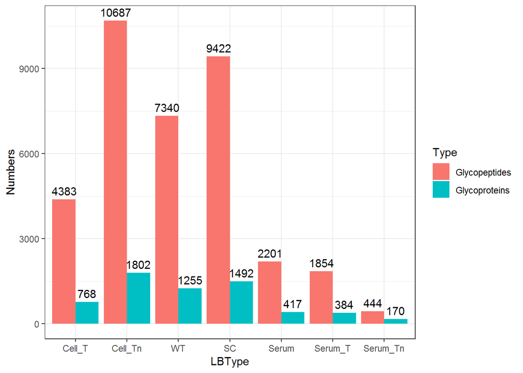

```r
ggplot(LbSum, aes(x = LBType, y = Numbers, fill = Type)) + geom_bar(stat = "identity", position = position_dodge()) + theme_bw() + geom_text(stat='identity', aes(label= Numbers), vjust= -0.5, nudge_x = c(-0.22, 0.22))
```

### Conclusions

- There are plenty of Tn-peptides in the WT library which were Jacalin enriched
- Tn-library is much larger than T-library after taking Tn-peptides from WT library

## Combined list

- Save in the folder “Spectronaut Library List/Combined List”
- Library Generation.R

```r
dir("Spectronaut Library List/Combined List")
```

```
## [1] "Cell_T.xls"   "Cell_Tn.xls"  "Exported"     "SC.xls"
## [5] "Serum.xls"    "Serum_T.xls"  "Serum_Tn.xls" "WT.xls"
```

## Reimport the libraries to Spectronaut and export again

- Save the libraries in “Spectronaut Library List/Combined List/Exported”

```r
dir("Spectronaut Library List/Combined List/Exported")
```

```
## [1] "Cell_T.xls"   "Cell_Tn.xls"  "SC.xls"       "Serum.xls"
## [5] "Serum_T.xls"  "Serum_Tn.xls" "WT.xls"
```

```r
source("R scripts/Exported Library Filter.R")
reshape2::dcast(LbSum, LBType ~ Type, value.var = 'Numbers')
```

```
##     LBType Glycopeptides Glycoproteins
## 1   Cell_T          4380           767
## 2  Cell_Tn         10667          1793
## 3       WT          7336          1252
## 4       SC          9407          1484
## 5    Serum          2201           417
## 6  Serum_T          1854           384
## 7 Serum_Tn           444           169
```

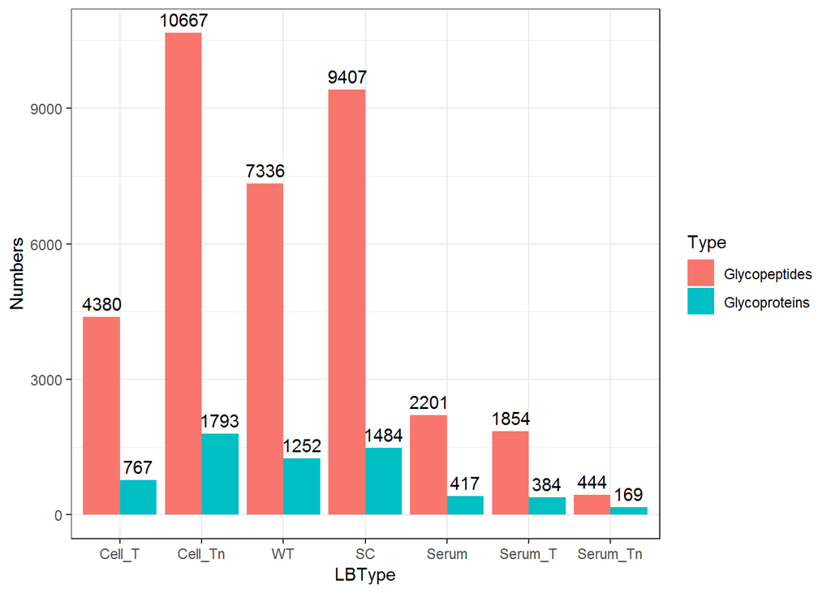

```r
ggplot(LbSum, aes(x = LBType, y = Numbers, fill = Type)) + geom_bar(stat = "identity", position = position_dodge()) + theme_bw() + geom_text(stat='identity', aes(label= Numbers), vjust= -0.5, nudge_x = c(-0.22, 0.22))
```

## Make in-silico libraries

- Take Serum.xls, Cell_T.xls and Cell_Tn.xls from “Spectronaut Library List/Combined List/Exported”
- Real library is first converted to Tn-library
- Then make T, STn, mST, dST and Naked libraries
- in silico Library.R

## Export the in-silico libraries

- Save in the folder “Spectronaut Library List/in silico library”
- Library Generation.R

```r
dir("Spectronaut Library List/in silico library")
```

```
##  [1] "dST_Library_Cell_T.xls"    "dST_Library_Cell_Tn.xls"
##  [3] "dST_Library_Serum.xls"     "mST_Library_Cell_T.xls"
##  [5] "mST_Library_Cell_Tn.xls"   "mST_Library_Serum.xls"
##  [7] "Naked_Library_Cell_T.xls"  "Naked_Library_Cell_Tn.xls"
##  [9] "Naked_Library_Serum.xls"   "STn_Library_Cell_T.xls"
## [11] "STn_Library_Cell_Tn.xls"   "STn_Library_Serum.xls"
## [13] "T_Library_Cell_T.xls"      "T_Library_Cell_Tn.xls"
## [15] "T_Library_Serum.xls"       "Tn_Library_Cell_T.xls"
## [17] "Tn_Library_Cell_Tn.xls"    "Tn_Library_Serum.xls"
```

## Align with the CCG database

- Glycosite Alignment.R
- Take the libraries from “Spectronaut Library List/Combined List/Exported”
- Merge all sequences and align with CCG database

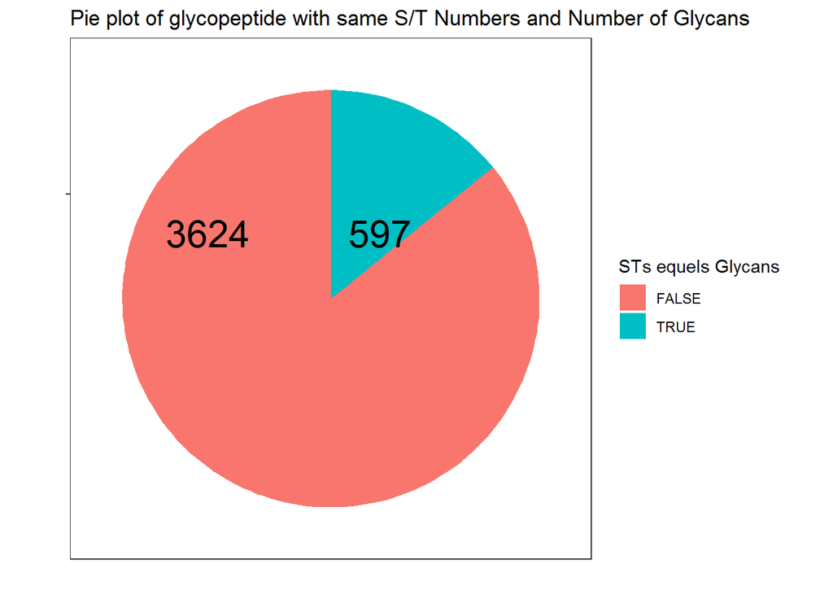

```r
source("R scripts/Glycosite Alignment.R")
Cell_T[["Pie"]]
```

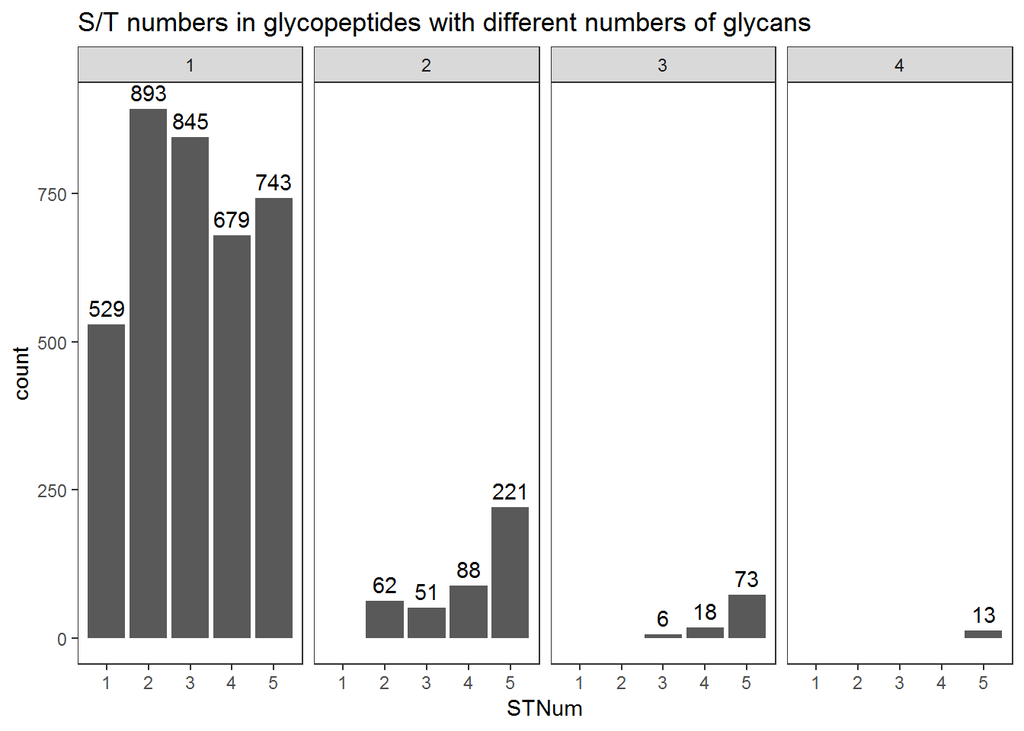

```r
Cell_T[["Bar"]]
```

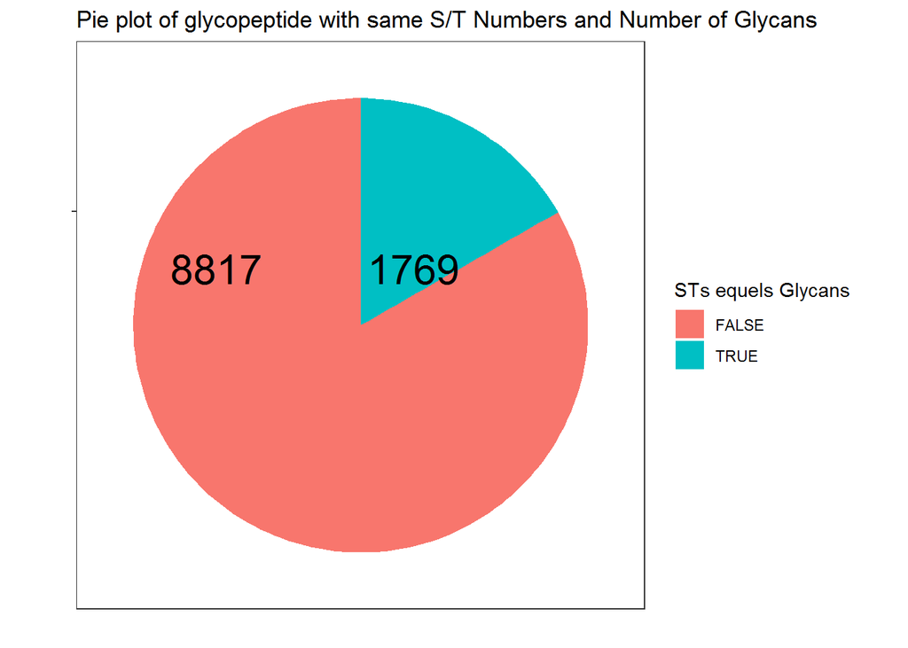

```r
Cell_Tn[["Pie"]]
```

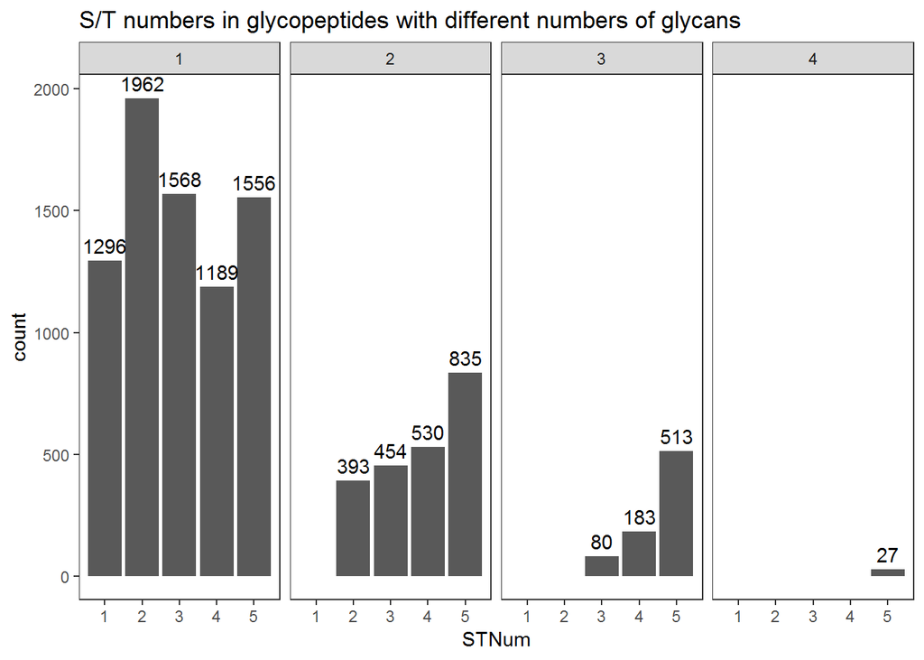

```r
Cell_Tn[["Bar"]]
```

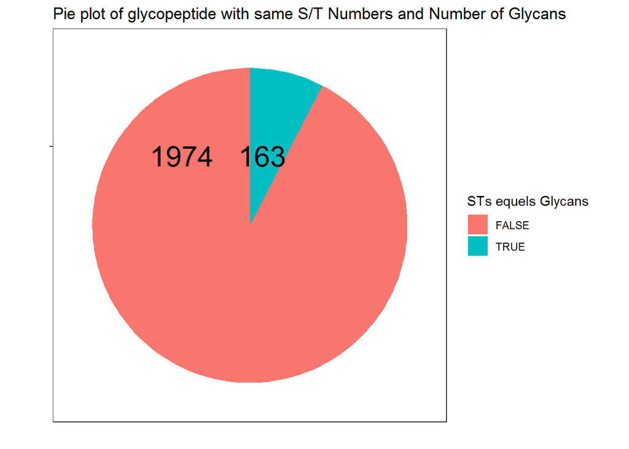

```r
Serum[["Pie"]]
```

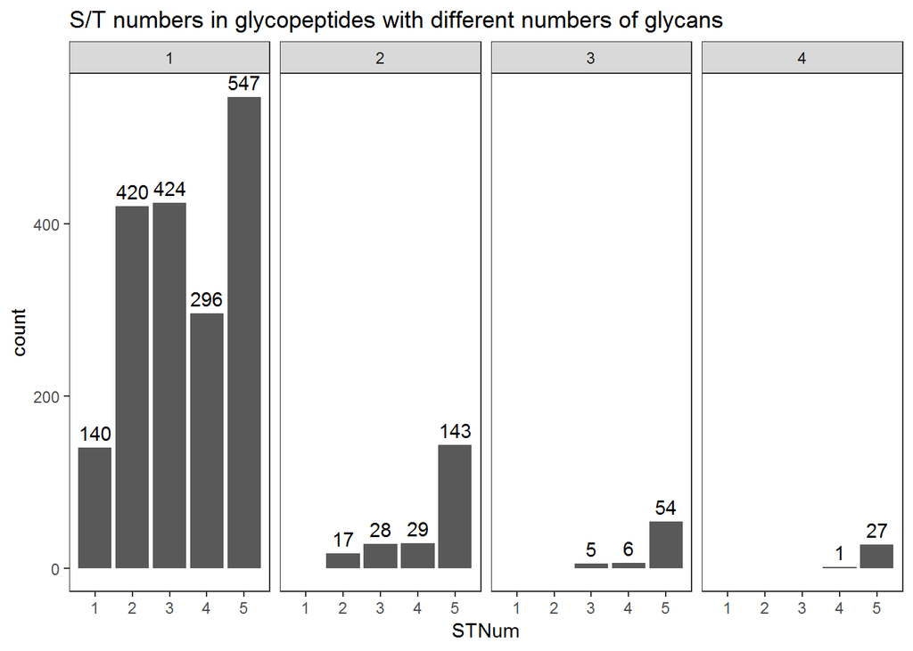

```r
Serum[["Bar"]]
```